# Hurricane Analysis and Visualization

Udit Ennam

April 30, 2018

## Introduction

- Hurricanes are one of the most deadliest natural disasters and highly unpredictable.
- There are 7 Tropical cyclone basins in the world: North Atlantic, South Atlantic, North Indian, South Indian, East Pacific, South Pacific, West Pacific.
- Goals of the project -
1. Is there a link between the number of hurricanes and the time of the year?
2. How frequent are the major hurricanes across different basins?

## Datasets

- Used National Oceanic and Atmospheric Administration (NOAA) to extract datasets of 7 recognized hurricane basins in the world.
- Datasets Parent URL : ftp://eclipse.ncdc.noaa.gov/pub/ibtracs/v03r03/wmo/csv/basin/
- 20 data fields taken into account to derive observations, analysis and make possible conclusions and visualizations.

## Hurricane Categorization

- Saffir-Simpson Scale is used to divide the hurricanes into 6 categories based on their wind speeds in miles per hour(mph)

| Category | Wind.Speed |
| --- | --- |
| 0 | Less Than 75 mph |
| 1 | 75 to 95 mph |
| 2 | 95 to 110 mph |
| 3 | 110 to 129 mph |
| 4 | 129 to 156 mph |
| 5 | Greater Than 156 mph |

## Visualization of the number of hurricanes based on category

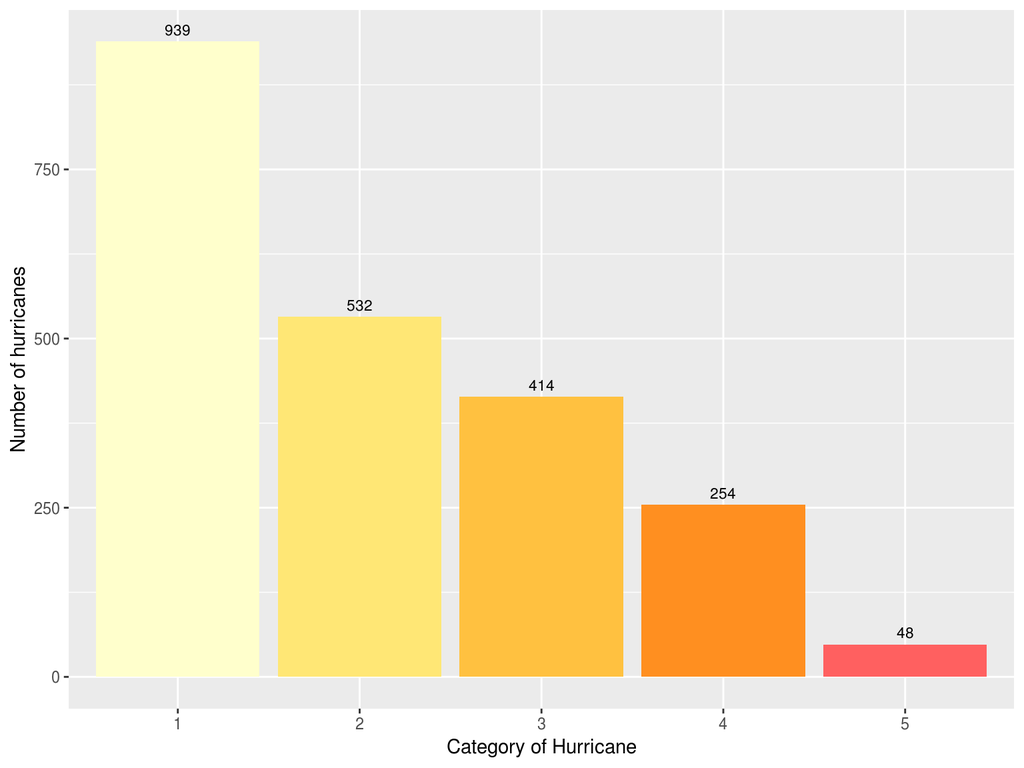

## Observation through Visualization

- Timeline of the dataset: 1848-2010

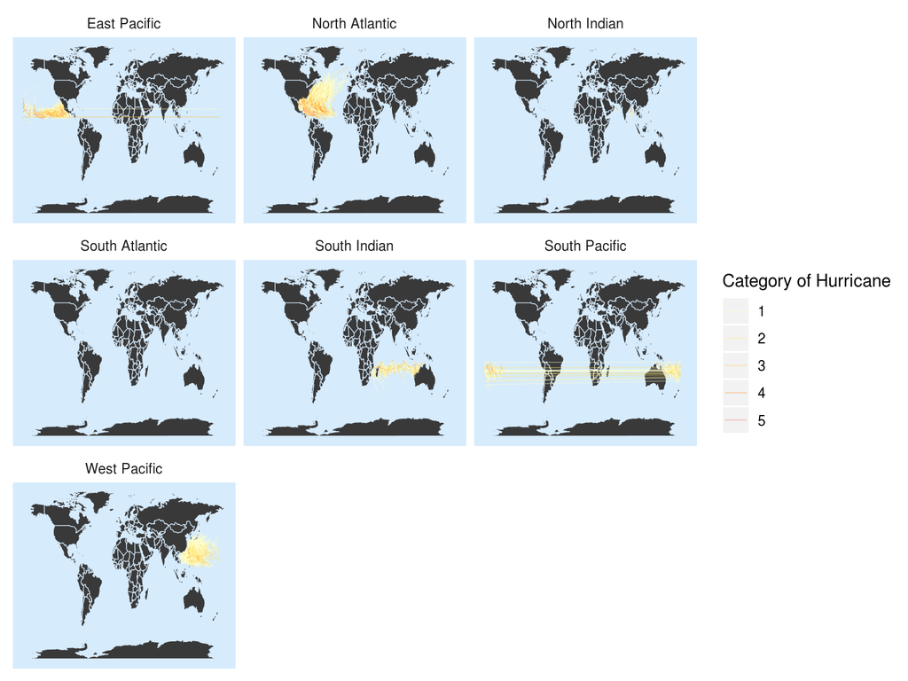

- North Atlantic, South Indian and the whole Pacific basin sees active hurricane occurrences.
- But we do not know the exact number of hurricanes nor the time of the year during which such occurrences take place.

## Distribution of hurricanes across the 7 basins

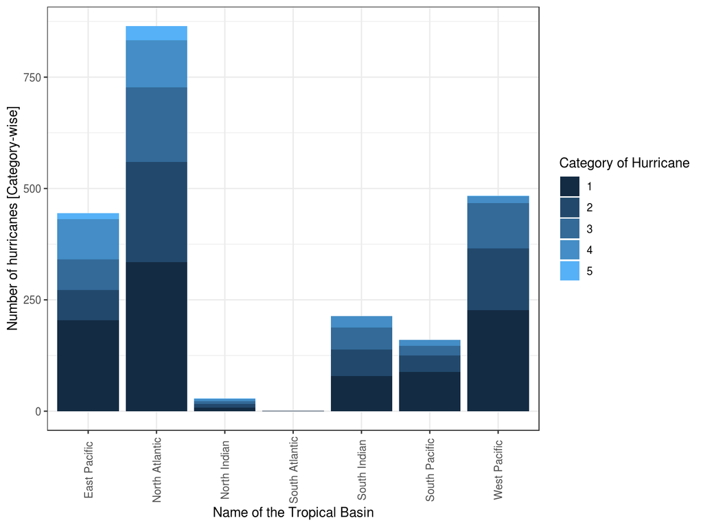

- South Atlantic Basin is least active for hurricanes, while North Atlantic is the most active, with Major hurricanes (Categories 3,4,5) amounting to about 40% of the overall hurricanes in the Basin.
- Adding Category 0 Hurricanes to the plot

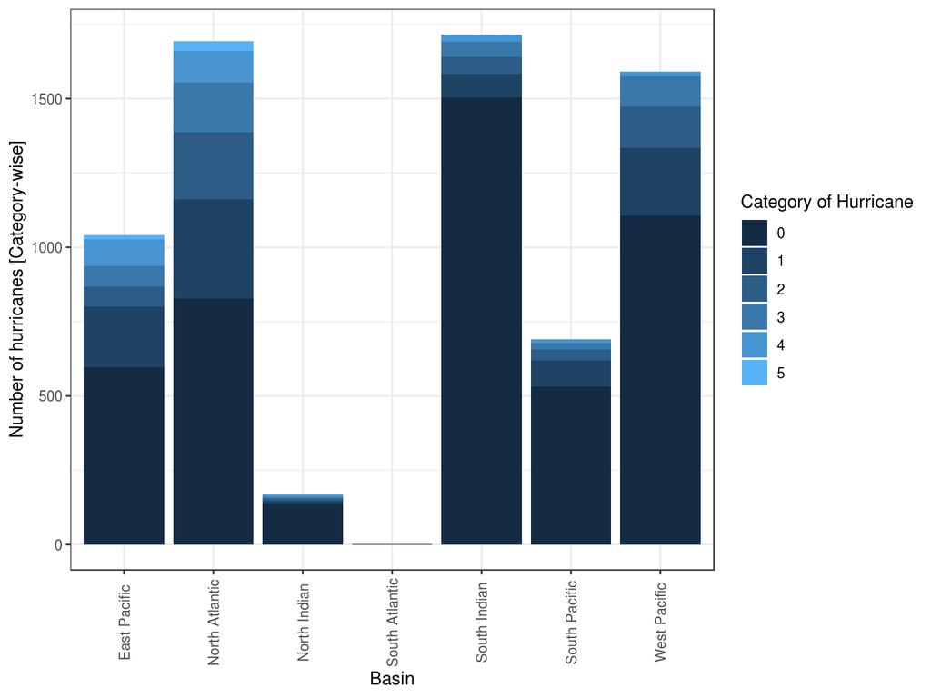

- South Indian Basin has the most number of Category 0 hurricane occurrences, which can later turn into higher category hurricanes, or higher category hurricanes may become less intense due to dry air, cooler land surfaces etc.

## Distribution of hurricanes around the United States of America

- We consider Hurricane Categories 1-5.

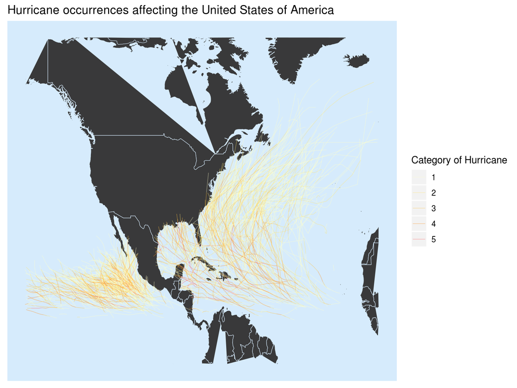

## Observation of hurricanes across each month

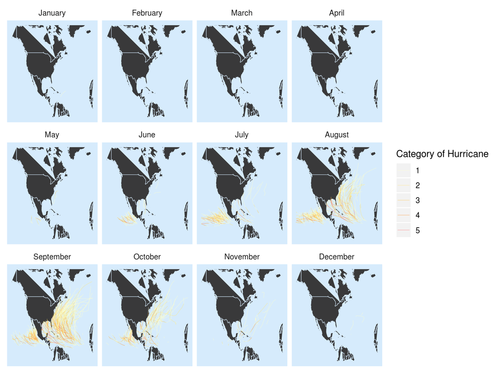

- Hurricane occurrences are frequent in the second half of the year from June to December, peaking during the months of August, September and October, around the United States.
- However, this does not give us the complete picture, that is, there might be other basins which are highly active during the earlier months.

## Number of hurricanes during each month from 1848 to 2010

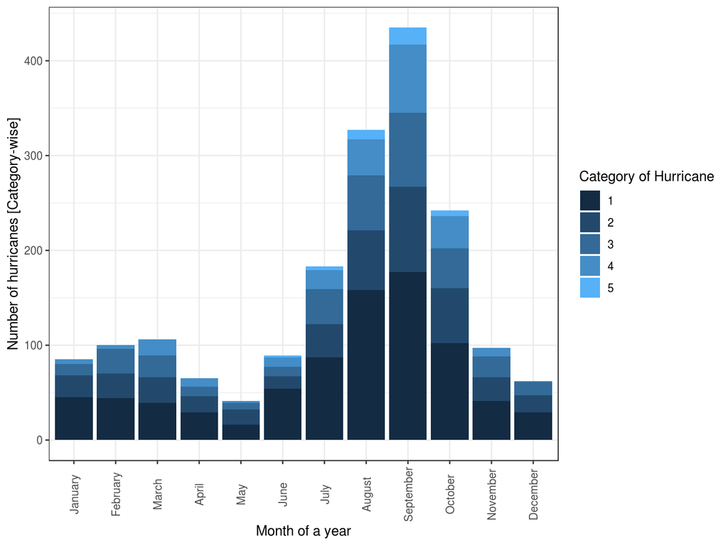

- As we observed in the facet plots, the numbers here provide proof that hurricane occurrences peak during August, September and October.
- All the tropical basins have been taken into account.

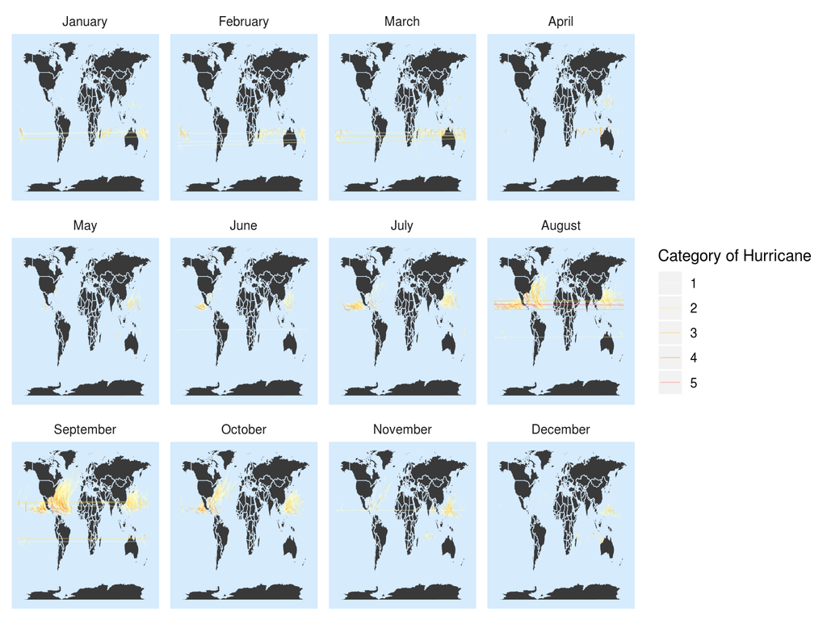

- When you plot the world map for each month and check the hurricane occurrences, we can see that, January To March sees a lot of hurricane activity in the Southern Hemisphere, precisely, the southern tropical cyclone basins.
- As April cometh, hurricane activities start surfacing in the Northern Hemisphere, continuing into May and June.
- Later on, the hurricane occurrences become stronger and frequent in the Northern Hemisphere, with only a few exceptions in the South.

## Is there a link between the time of the year and the activity in a tropical cyclone basin?

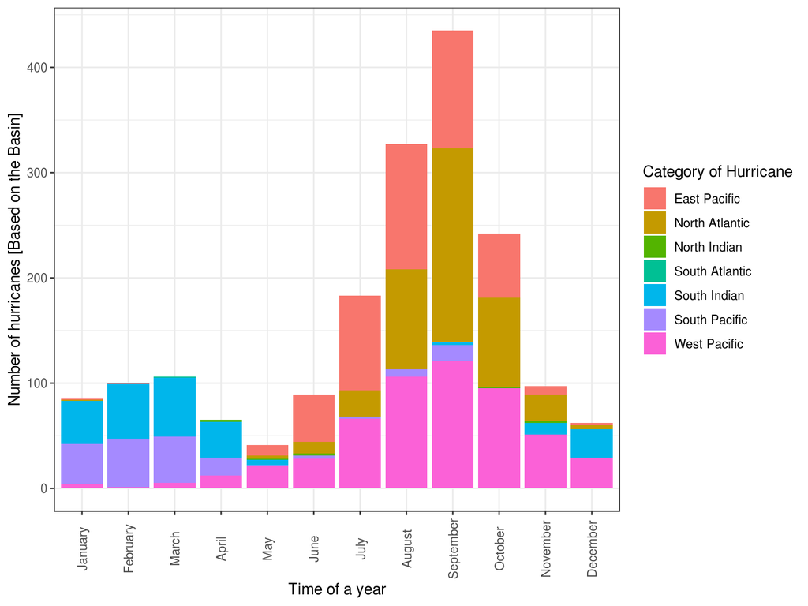

- North Atlantic, as we know, proves the official season from June to November.
- Most active basins during the second half of the year are: East Pacific, North Atlantic and West Pacific.
- Active basins during the first half of the year are: South Indian and South Pacific.
- YES, there definitely seems to be a link between the basin activity and the time of the year Southern basins active during the first half and the northern, central basins active during the second half of a year.

## Conclusion

- North Atlantic basin is the most active and cause for major damages through the months of June to November.
- South Indian and South Pacific are active basins during the first six months of a calendar year.
- There are definitely links between the number of hurricanes and the time of the year, with the tropical cyclone basins adding their significance.
- This could help in alerting and taking measures to spread awareness among people living in the most likely and highly affected areas in the tropical basins, during the different times of a year.
- Further steps can be taken to check if global warming has had any effect on the number of major hurricanes occurrences during 2000-2010.